# Checking 62 genes from Fe’s metabolism

Examination of p0 an p21 of POMC neurons

Elena Eyre, PhD

2022-05-13

# 1 Load

## 1.1 Libraries of functions:

I uploaded data and packages of necessary functions to perform the calculations, and set the working directory.

## 1.2 Data

I load the mouse model Ribotag CPM data.

I also load of the metadata from the Ribotag mouse model.

```r
#metadata <- read_excel("/Volumes/ELENA_2/Trab_Elena/IDIBAPS/Roberta_Networks_Depict_and_GWAS/Extraction_Raw_data_RNAseq_POMCRibotag_P0vsP21_HFD.xlsx",
#    sheet = "Metadata")
metadata <- read_excel("G:/Trab_Elena/IDIBAPS/Roberta_Networks_Depict_and_GWAS/Extraction_Raw_data_RNAseq_POMCRibotag_P0vsP21_HFD.xlsx",
    sheet = "Metadata")
```

The list of genes I obtained from the website provided by Marc (https://rgd.mcw.edu/rgdweb/pathway/pathwayRecord.html?acc_id=PW:0000590&species=Mouse#gviewer).

# 2. Exploration of the data

## 2.1 Fe’s metabolism gene list

This is the table where there is the list of genes of interest (second column). I observed there are 64 rows but 62 unique genes because Pcbp1 and Pcbp2 participate in 2 different pathways.

```
## [1] "Genes: 64 ; and parameters: 7"
```

Section of gene list associated to Fe metabolism.

| RGD ID | Symbol | Chromosome | Start Position | Stop Position | Assembly | Pathway |
| --- | --- | --- | --- | --- | --- | --- |
| 10066 | Aco1 | 4 | 40143265 | 40199009 | GRCm38 | iron homeostasis pathway |
| 1315758 | Fbxl5 | 5 | 43744618 | 43782149 | GRCm38 | iron homeostasis pathway |
| 736754 | Ireb2 | 9 | 54862658 | 54912534 | GRCm38 | iron homeostasis pathway |
| 1615936 | Ncoa4 | 14 | 32159879 | 32179855 | GRCm38 | iron homeostasis pathway |
| 1557062 | Pcbp1 | 6 | 86524480 | 86526189 | GRCm38 | iron homeostasis pathway |
| 1320066 | Pcbp2 | 15 | 102470450 | 102500068 | GRCm38 | iron homeostasis pathway |

## 2.2 Pre-process Ribotag’s data

Exploration of the Raw Ribotag’s data (normalized in CPMs):

```
## [1] "Genes: 15355 ; and samples and probes' columns: 18"
```

Section of CPM’s table from Ribotag’s data

| gene | C48 | C51 | C55 | C63 | C69 |
| --- | --- | --- | --- | --- | --- |
| Sept1 | 0.464294 | 0.9609779 | 0.5160707 | 0.6374535 | 0.680663 |
| Mars2 | 4.236682 | 9.8099831 | 5.0316896 | 3.7450392 | 5.205070 |
| Sept2 | 86.445733 | 68.1093109 | 70.2823820 | 60.6776035 | 63.421773 |
| Sept3 | 659.152338 | 654.8263790 | 526.5211580 | 604.5449477 | 709.931478 |
| Sept4 | 23.998194 | 20.5008625 | 35.2218270 | 19.2829679 | 19.378875 |
| Sept5 | 83.747024 | 100.6624383 | 108.7296510 | 132.1919162 | 132.649201 |

Exploration of the metadata’s related to Ribotag’s data:

```
## [1] "Samples: 17 ; and parameters: 4"
```

| Group | Sample | Diet | Time |
| --- | --- | --- | --- |
| CD0 | C48 | CD | 0 |
| CD0 | C51 | CD | 0 |
| CD0 | C55 | CD | 0 |
| CD0 | C63 | CD | 0 |
| CD0 | C69 | CD | 0 |
| CD21 | C42 | CD | 21 |
| CD21 | C43 | CD | 21 |
| CD21 | C79 | CD | 21 |
| HFD0 | H10 | HFD | 0 |
| HFD0 | H14 | HFD | 0 |
| HFD0 | H18 | HFD | 0 |
| HFD0 | H19 | HFD | 0 |
| HFD0 | H57 | HFD | 0 |
| HFD21 | H26 | HFD | 21 |
| HFD21 | H35 | HFD | 21 |
| HFD21 | H39 | HFD | 21 |
| HFD21 | H49 | HFD | 21 |

# 3. Pre-processing

## 3.1 Presence of specific genes:

Definition of the list to check.

```
## [1] "Length of the gene list: 62 genes"
```

## 3.2 Set the working table

```
## [1] 0
```

```
## [1] "Dimensions of the table: 56 genes, and  18 (1 probes' column + 17 samples)"
```

| gene | C48 | C51 | C55 | C63 | C69 |
| --- | --- | --- | --- | --- | --- |
| Aco1 | 36.21493 | 41.12185 | 62.76710 | 45.81697 | 63.78212 |
| Fbxl5 | 91.20475 | 76.39775 | 102.66582 | 115.89701 | 90.76841 |
| Ireb2 | 44.65928 | 77.35872 | 53.83263 | 58.80508 | 58.37686 |
| Ncoa4 | 97.03744 | 114.03605 | 122.79258 | 109.96073 | 119.87676 |
| Pcbp1 | 189.11274 | 249.81422 | 198.65498 | 222.90952 | 277.83061 |
| Pcbp2 | 61.75110 | 68.79000 | 41.28566 | 41.79304 | 50.20890 |

# 4. Expression levels

Second, I need to explore the expression levels of those genes that are present.

## 4.1 Visualization

First, I explore the expression levels of all the available cells:

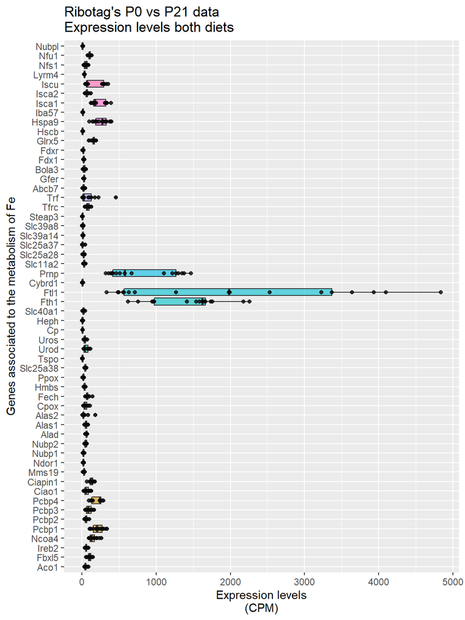

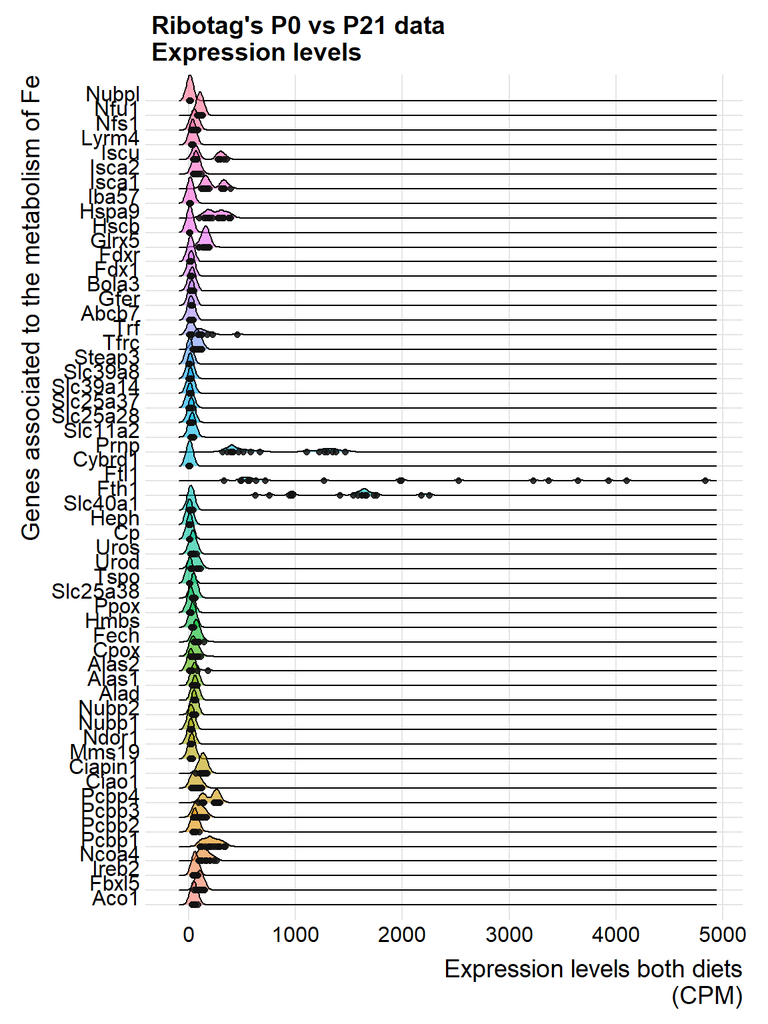

Due to we considered different diet and time-course groups, I split the plots into facets.

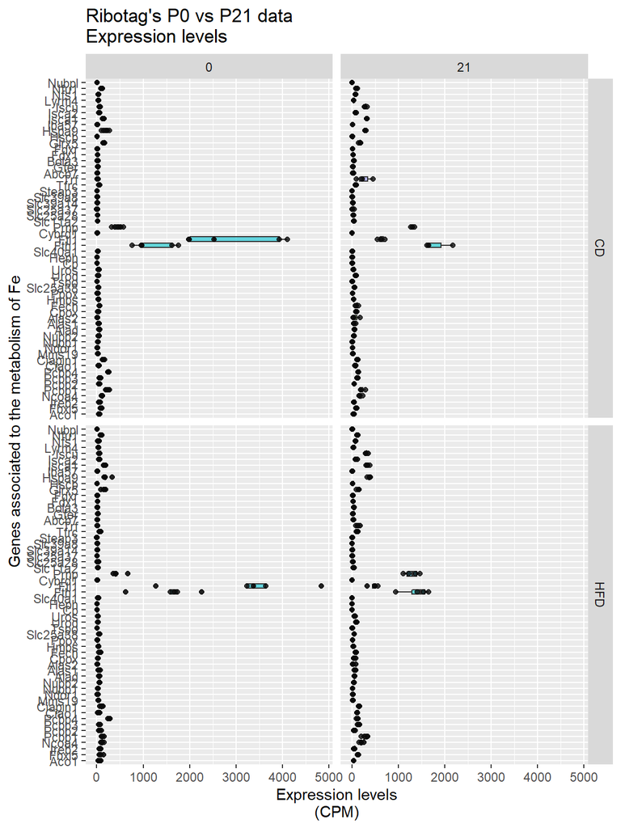

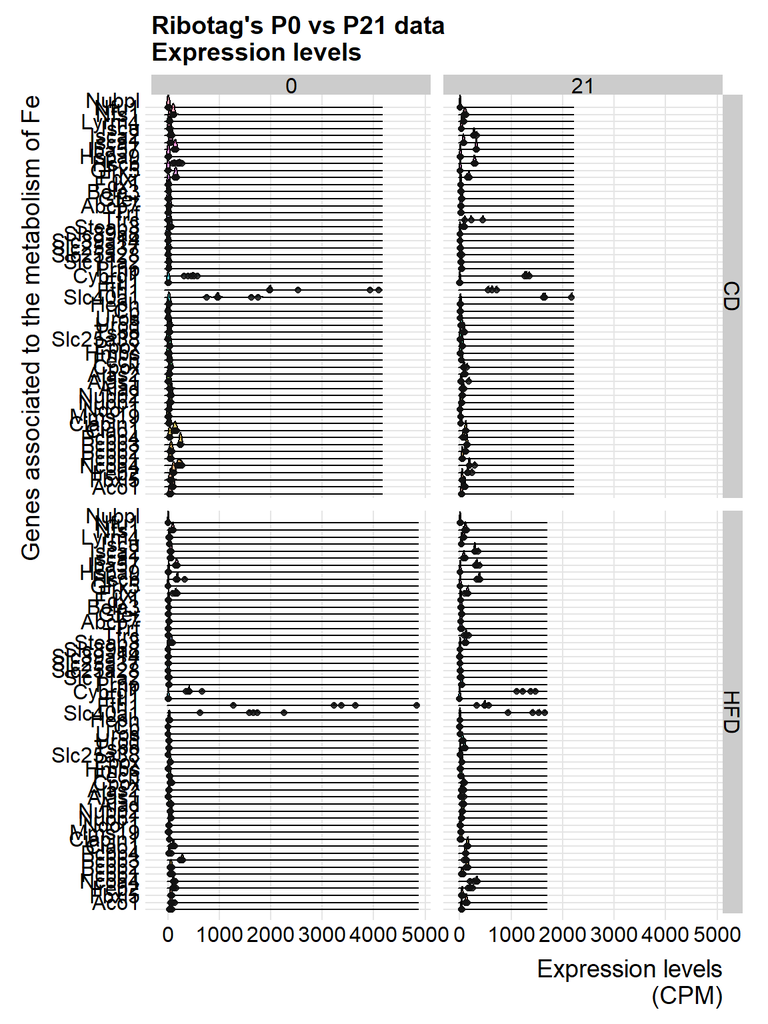

Thanks to this, I can observe clear changes in some genes in time such as Fth1 and Ftl1.

To improve this visualization, I reverse one of the facets and assign different colors to it:

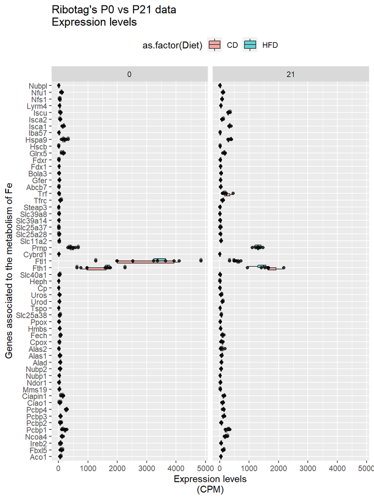

## 4.2 Log2 visualization

First, I log2 transform the expression levels because I realized the expression levels’ changes of genes that express higher levels may mask the changes of genes that express lower levels:

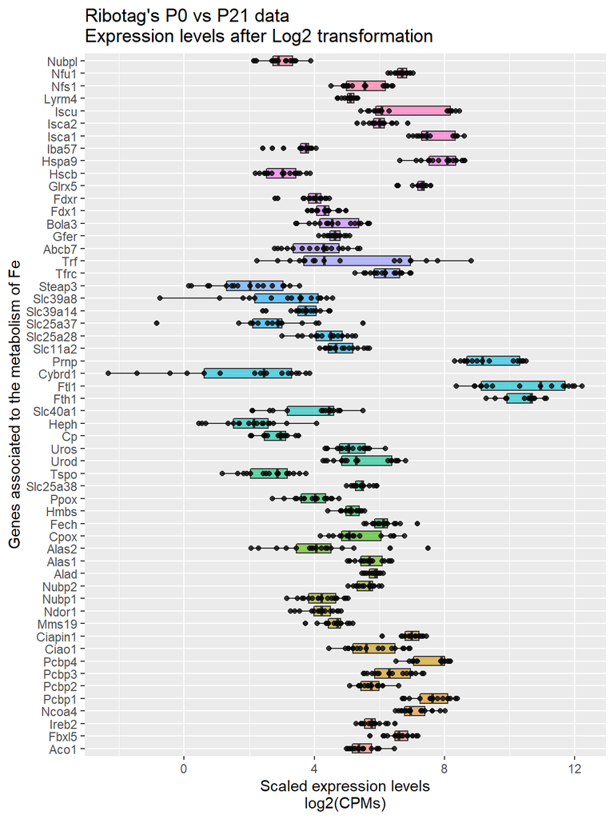

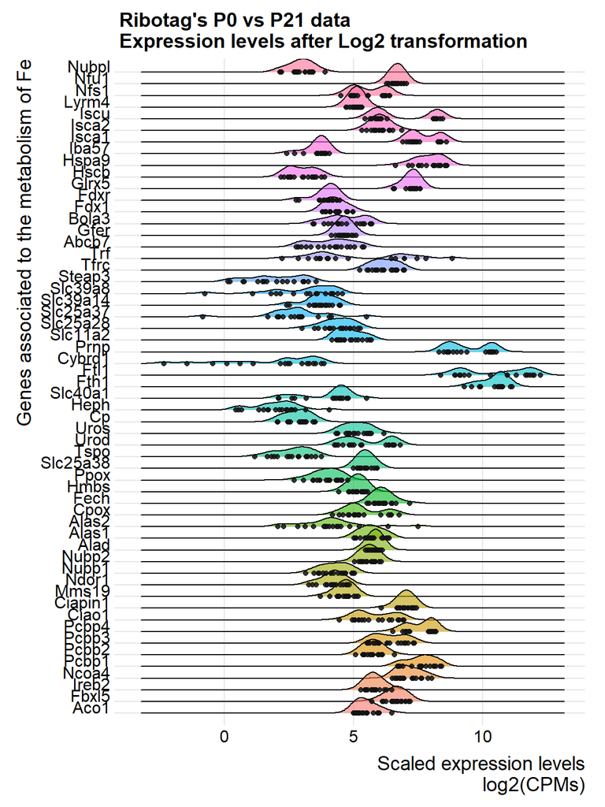

Due to we considered different diet and time-course groups, I split the plots into facets.

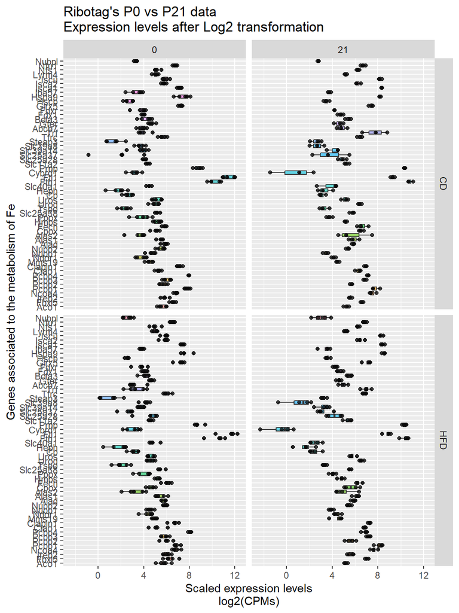

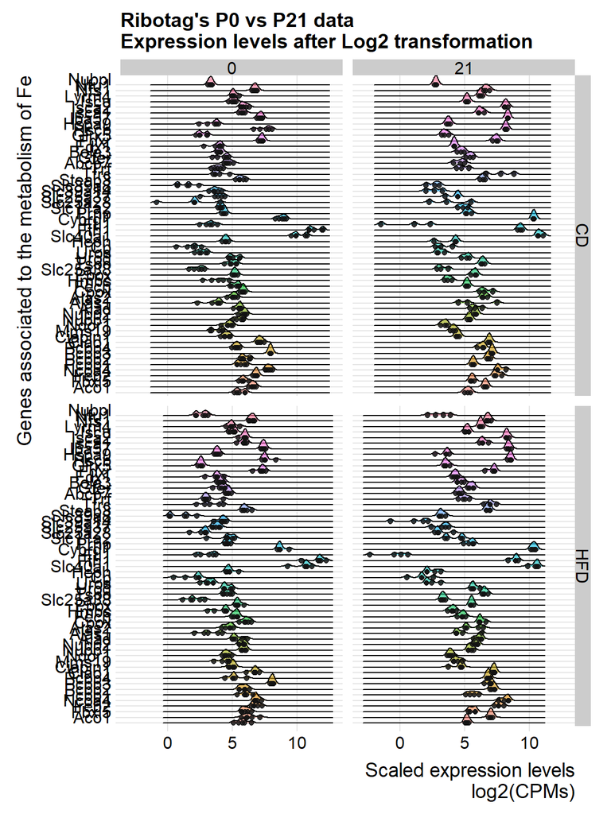

Thanks to this, I can observe clear changes in some genes in time such as Fth1 and Ftl1.

To improve this visualization, I reverse one of the facets and assign different colors to it:

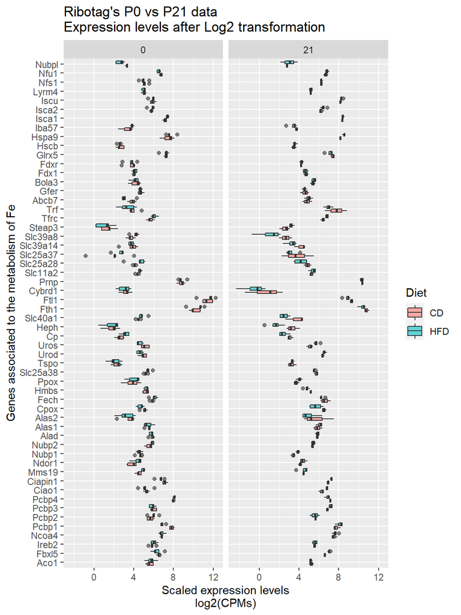

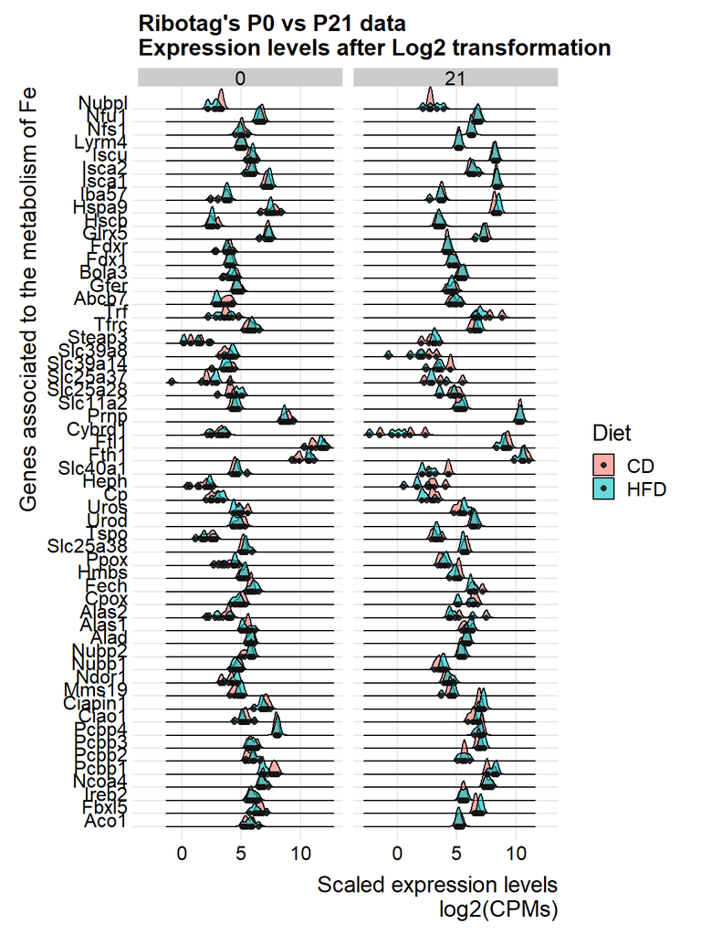

If I try to include another variable per gene, customize the colors and turn right the plot:

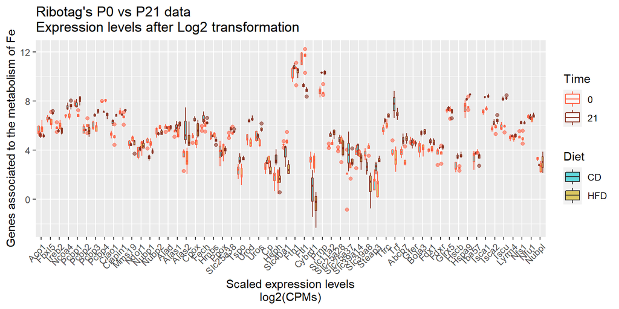

If I also want to add statistics I need to split it again:

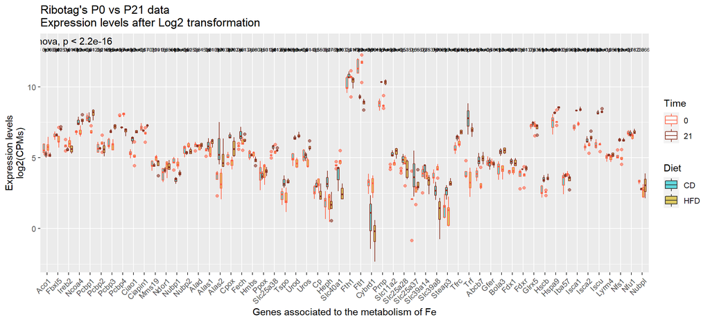

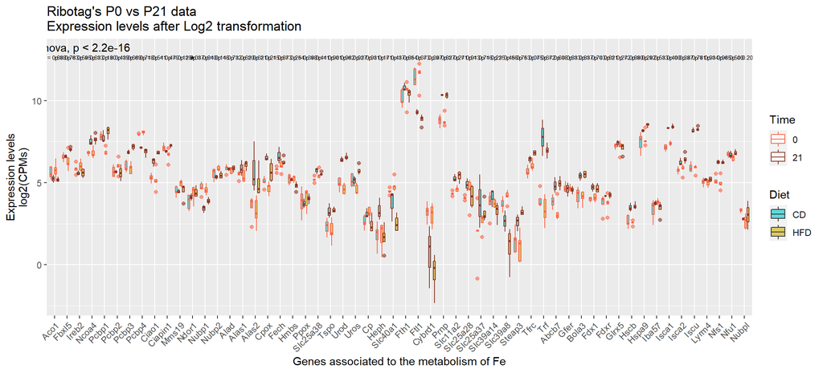

## 4.3 Visualization CD

In order to observe what happens in a normal situation, I extract the Chow diet:

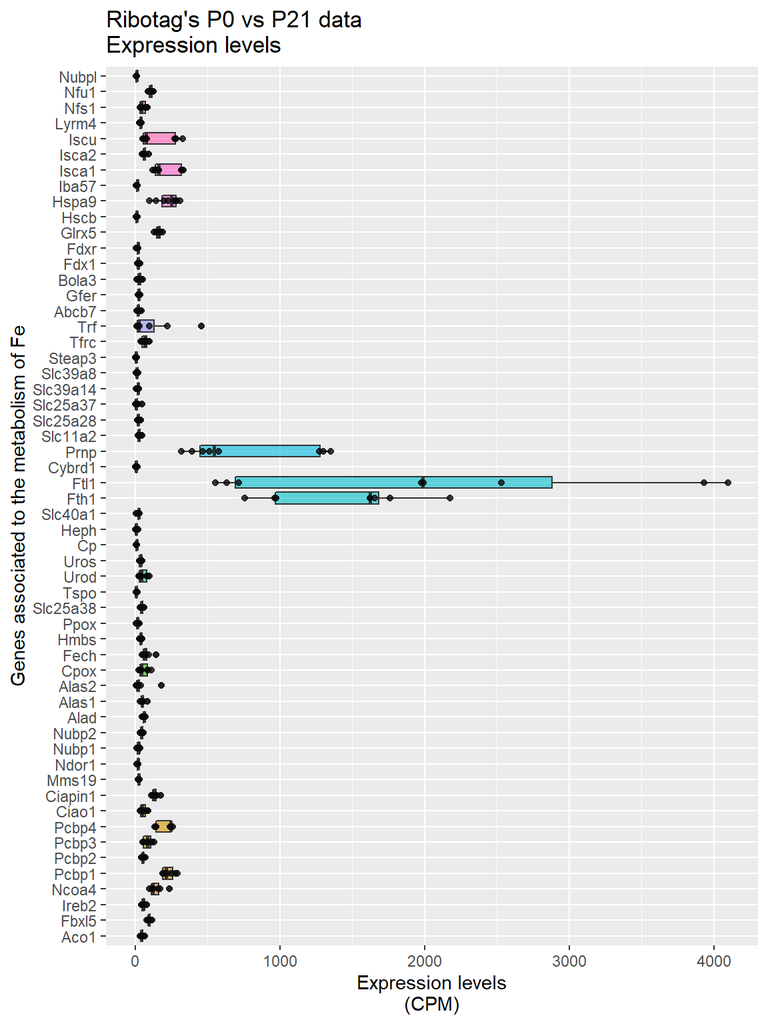

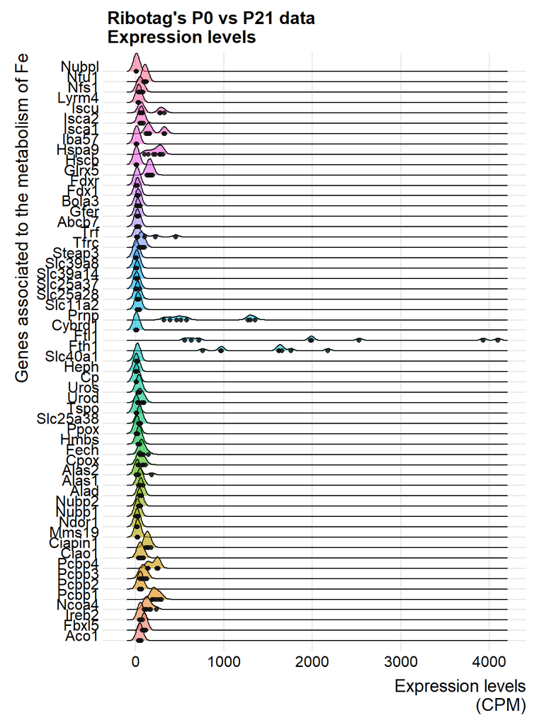

Due to we considered different time-course groups, I split the plots into facets.

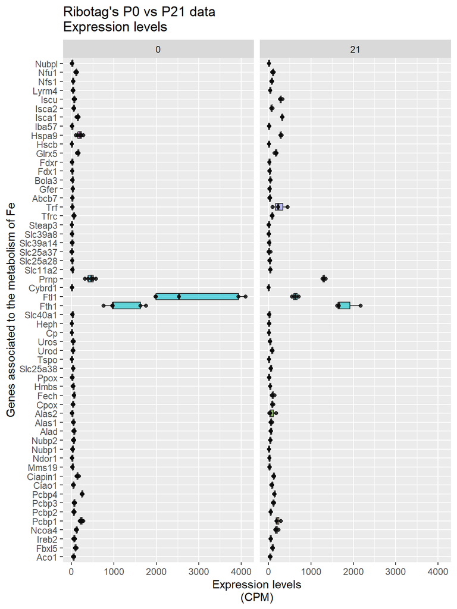

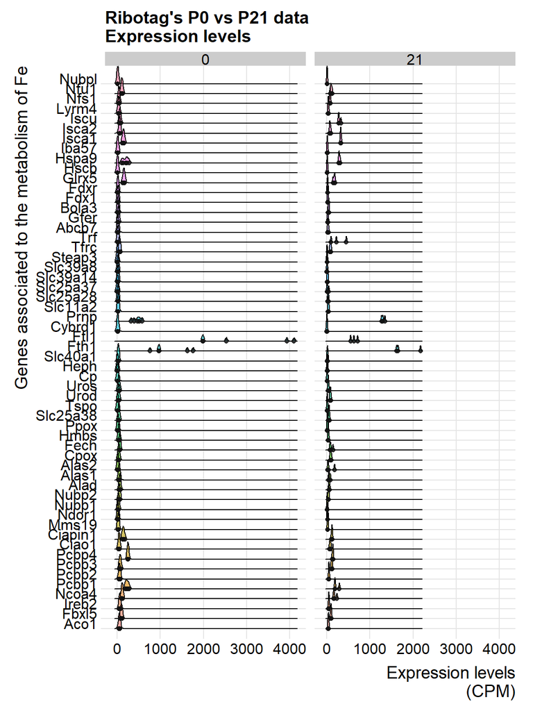

Thanks to this, I can observe clear changes in some genes in time such as Fth1 and Ftl1.

To improve this visualization, I reverse one of the facets and assign different colors to it:

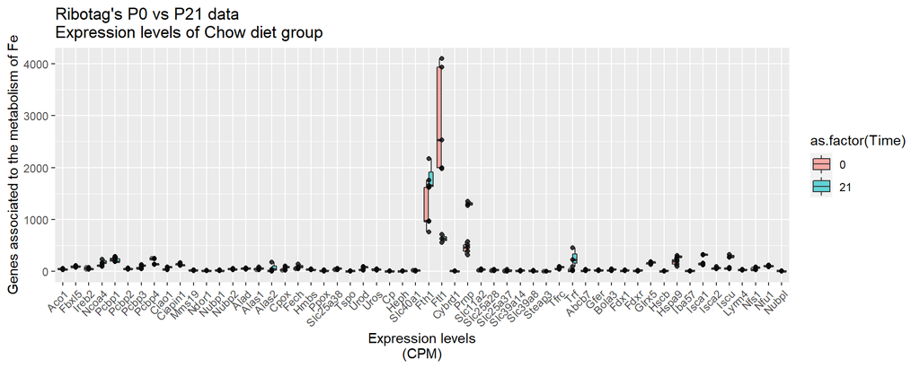

## 4.4 Log2 visualization of Chow diet

I already had the log2 transformation from the table I have filtered:

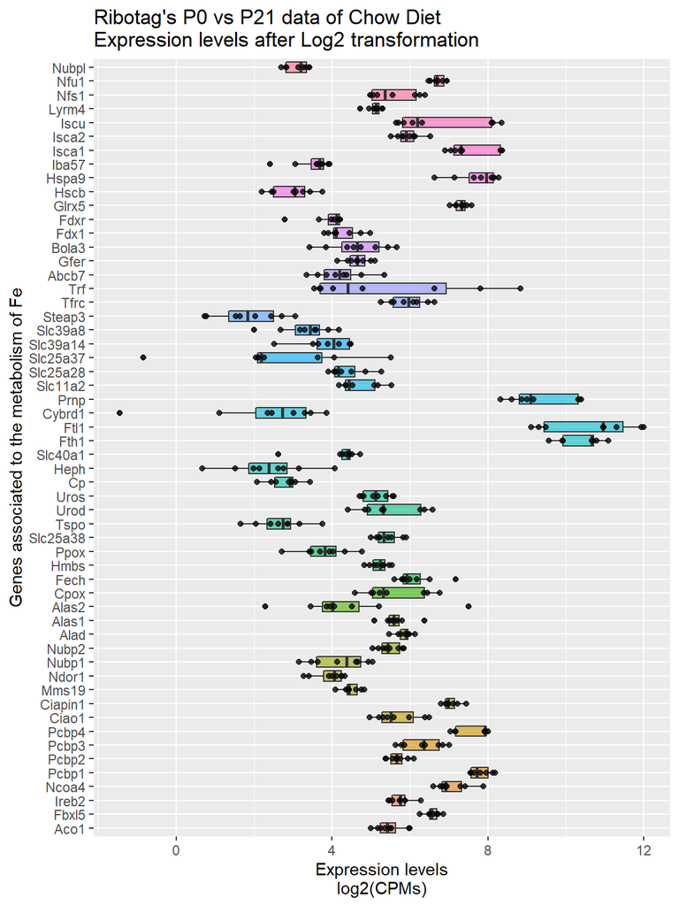

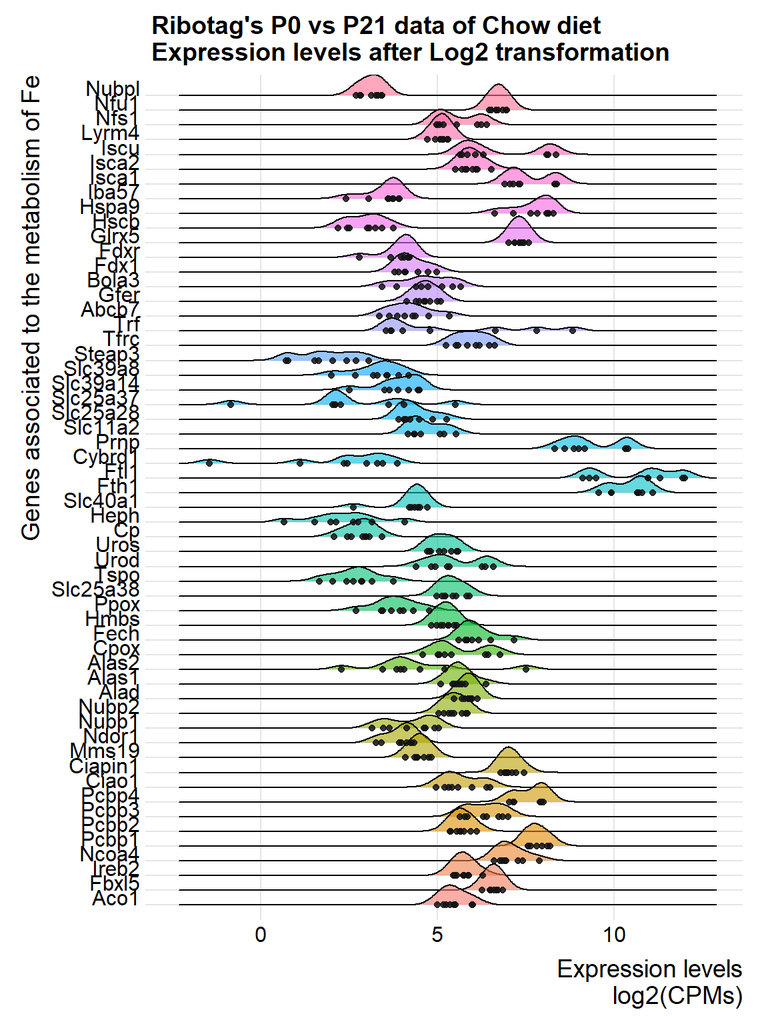

Due to we considered different time-course groups, I split the plots into facets.

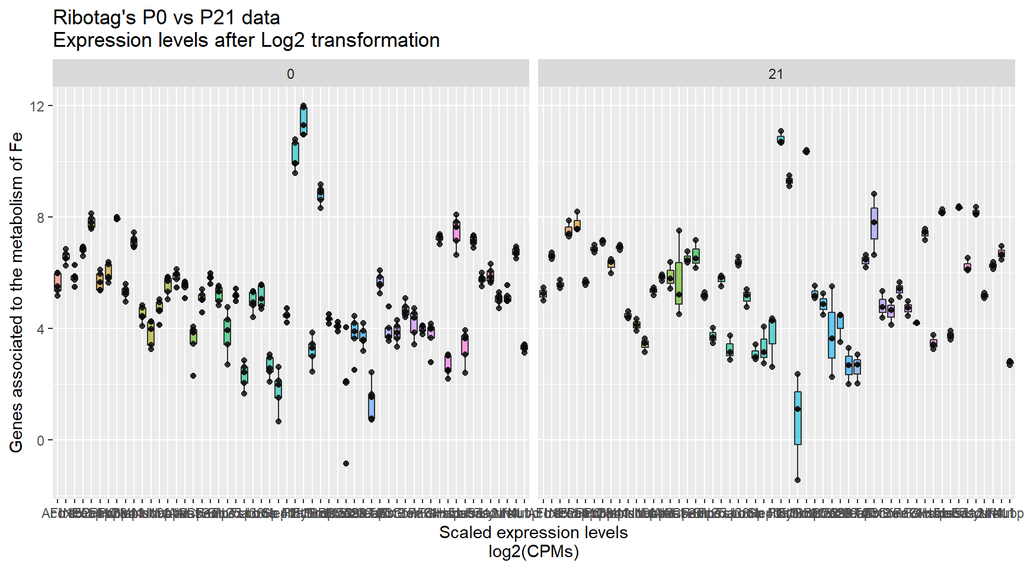

To improve this visualization, I reverse one of the facets and assign different colors to it:

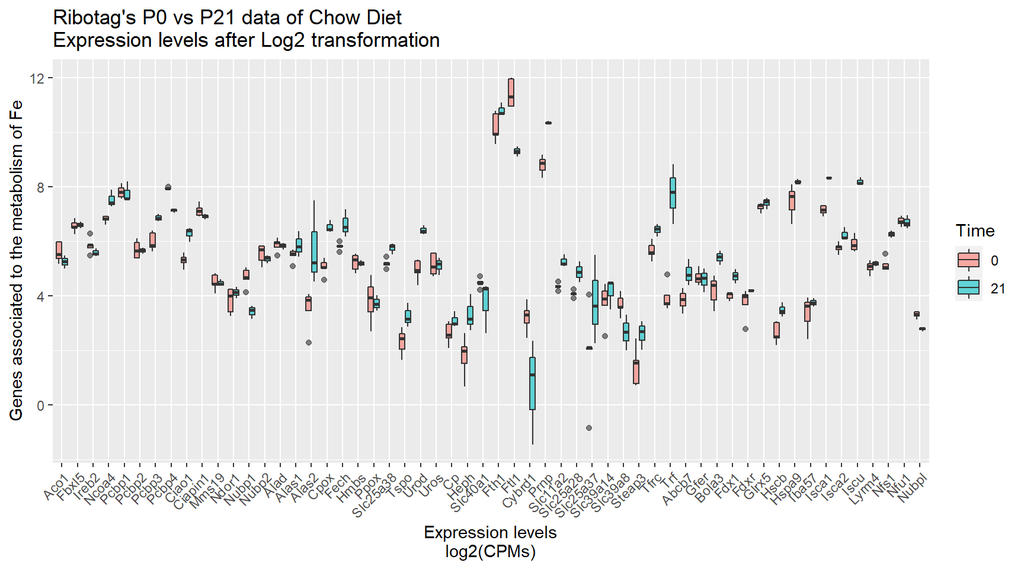

If I also want to add statistics I need to split it again:

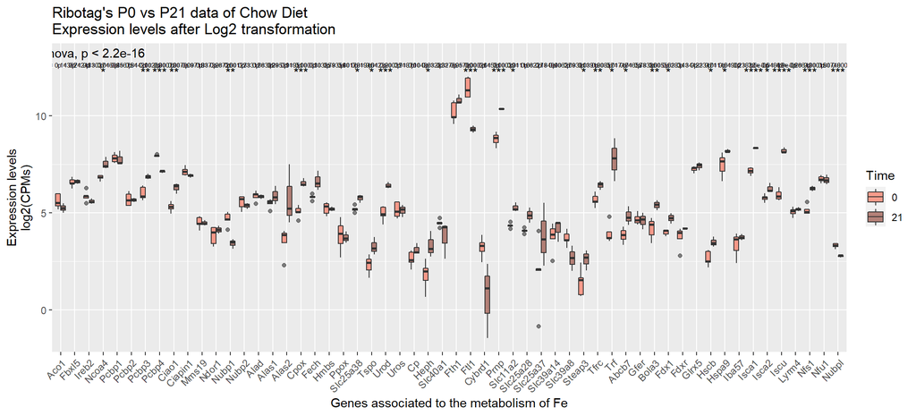

## 4.5 Log transformation FC

Due to it seems better to interpret, Sara suggested to visualize Chow diet data in fold changes of P21 vs P0:

```r
df3 <- as.data.frame(t(df2[,-1]))
colnames(df3) <- df2$gene
df3$Sample <- rownames(df3)
df3 <- left_join(metadata, df3, by= 'Sample')
rownames(df3) <- df3$Sample
library(reshape2)
df2 <- df2 %>%
  mutate(CD0_mean = rowMeans(df2[,2:6])) %>%
  mutate(CD21_mean = rowMeans(df2[,7:9])) %>%
  mutate(FC = CD21_mean/CD0_mean)

Probes <- unique(df5$variable)
df6 <- df2[,c(1,21)]
df6$Log2_FC <- log2(df6$FC)
df6$FC_trend <- if_else(df6$Log2_FC > 0, "Up","Down")
#df6$gene <- reorder(df6$gene, df2$gene)
#df6$reference <- sapply(df6$gene, function(x) which(x == df2$gene))
df6 <- df6[order(match(df6$gene, Probes)),]
pdf(file = "Boxplots_Fe_associated_genes_Ribotag_P0P21_Timestatistics_Log2FC_ChowDiet.pdf", width = 12, height = 15)
g1 <- ggplot(df6,aes(Log2_FC, Probes)) + geom_col(aes(Log2_FC, Probes,fill = as.factor(FC_trend)),alpha = 0.6)+labs(y="Genes associated to the metabolism of Fe",x="Expression levels\nLog2(FC)")+ggtitle("Ribotag's P0 vs P21 data\nLog2 transformed Fold changes (P21 means/P0 means)")+ theme(legend.position = "none")+ scale_fill_manual(values = c("Up" = "tomato", "Down" = "deepskyblue1"))
g1
dev.off()
```

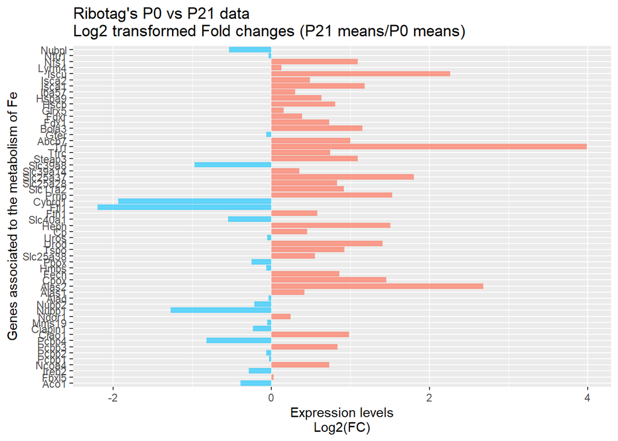

```r
g1
```